*Master IASD, PSL - 2025-2026 - O. Cappé, October 2025*

# Retail Store Management

**This is your INDIVIDUAL homework that needs to be returned by November 30, 2025, at the latest, as a functional completed Python notebook file. Late submissions will be applied a penalty.** Please print your name here and be sure to name your file `YourFirstName-YOURLASTNAME-retail_store.ipynb` and to send it by email to olivier.cappe@ens.fr before the deadline.

We consider, the *retail store management* model seen in the course (Ex. 1.2).

You own a bike store. During week $t$, the demand is $D_t$ units, which we may assume to be $\operatorname{Poisson}(d)$ distributed, independently of the past. On Monday morning you may choose to command $A_t$ additional units that are delivered immediately before the shop opens. For each week,

- Maintenance Cost: $h$ per unit left in your stock from previous week
- Ordering Cost: $c$ per ordered unit
- Sales Profit: $f$ per sold unit

With the following constraints

- Your warehouse has a maximal capacity of $m$ unit (any additional bike gets stolen)
- You cannot sell bikes that you don’t have in stock

We will consider that $\mathcal{A}=\mathcal{S}=\{0,\dots,m\}$ and the MDP evolves according to

- $D_t \sim \operatorname{Poisson}(d)$
- $X_t = -h S_t -c A_t + f \min(D_t, S_t + A_t, m)$
- $S_{t+1} = \max(0, \min(S_t+A_t,m)-D_t)$

```python
# Please REFRAIN from importing any additional module
import math
import numpy as np
from scipy.stats import poisson
import matplotlib.pyplot as plt
```

## The Retail Store Environment

The `RetailStore` class defines the environnement, providing the basic functions for interacting with the system (`env.reset` and `env.step`) and for computing basic parameter-dependent quantities (reward and transition functions, value function of a policy).

```python
# Utility functions for the Retail store environment (do NOT modify this code block)

class RetailStore:
    def __init__(self, m, h, c, f, d):
        self.m = m # Stock capacity
        self.h = h # Maintenance cost per unit
        self.c = c # Buying price per unit
        self.f = f # Selling price per unit
        self.d = d # Weekly average demand

    def reset(self, state):
        """ Restarts the environment at time 0 in specified state. """
        self.state = state
        self.time = 0

    def step(self, action):
        """ Given the action, performs one call to the environment and return the reward. """
        demand = poisson.rvs(self.d)
        reward = -self.h*self.state -self.c*action + self.f*min([demand, self.state+action, self.m])
        # Update the time and state variables
        self.time += 1
        self.state = max([min([self.state+action, self.m])-demand, 0])
        return reward

    def reward_function(self):
        """ Computes the action-depend reward function r(s,a). """
        r = np.zeros((self.m+1, self.m+1))
        for s in range(self.m+1):
            for a in range(self.m+1):
                # Note: computing the expectation of the truncated Poisson distribution using the survival function
                r[s, a] = -self.h*s -self.c*a + self.f*sum(poisson.sf(np.linspace(0, min(s+a, self.m)-1, num=min(s+a, self.m)), self.d))
        return r

    def transition_function(self):
        """ Computes the action-depend transition probabilities p(s,a,s'). """
        p = np.zeros((self.m+1, self.m+1, self.m+1))
        for s in range(self.m+1):
            for a in range(self.m+1):
                for i in range(min(s+a, self.m)):
                    p[s, a, min(s+a, self.m)-i] = poisson.pmf(i, self.d)
                p[s, a, 0] = poisson.sf(min(s+a, self.m)-1, self.d)
        return p

    def reward_policy(self, pi):
        """ Computes the reward function r_pi(s) associated with a policy. """
        r = self.reward_function()
        r_pi = np.sum(np.multiply(r, pi), axis=1)
        return r_pi

    def transition_policy(self, pi):
        """ Computes the transition probabilities p_pi(s,s') associated with a policy. """
        p = self.transition_function()
        p_pi = np.zeros((self.m+1, self.m+1))
        for s in range(self.m+1):
            p_pi[s,:] = np.matmul(np.transpose(pi[s,:]), p[s,:,:])
        return p_pi

    def value_policy(self, pi, gamma):
        """ Computes the value function of a policy, with discount gamma (using matrix inversion). """
        r_pi = self.reward_policy(pi)
        p_pi = self.transition_policy(pi)
        v_pi = np.linalg.solve(np.eye(self.m+1) - gamma* p_pi, r_pi)
        return v_pi
```

## Experiments

### Q1. Performance of Fixed Ordering Policies

In all the homework, we will consider a small-size model in which $[m, h, c, f, d, \gamma] = [9, 0.1, 0.5, 1, 4, 0.875]$.

```python
# Instantiate the retail store environment with the selected parameters
[m, h, c, f, d, gamma] = [9, 0.1, 0.5, 1, 4, 0.875]
env = RetailStore(m, h, c, f, d)

# Just an example of simulating a short trajectory and computing the cumulated reward
env.reset(m)
n = 12
w = 1
v = 0
for _ in range(n):
    x = env.step(3)
    print(env.time-1, ': ', '{:.1f}'.format(x), ' ->', env.state)
    v += w*x
    w *= gamma
print('Discounted reward:', '{:.1f}'.format(v))
```

```
0 :  0.6  -> 6
1 :  0.9  -> 6
2 :  -0.1  -> 7
3 :  -2.2  -> 9
4 :  -0.4  -> 7
5 :  -0.2  -> 7
6 :  1.8  -> 5
7 :  3.0  -> 3
8 :  4.2  -> 0
9 :  1.5  -> 0
10 :  1.5  -> 0
11 :  1.5  -> 0
Discounted reward: 4.1
```

In this first question we are interested in the performance of fixed-ordering policies (i.e. ordering always the same quantity of goods).

1. Estimate, using Monte Carlo runs, **the value function associated with the policy that always order 3 items each week**. **Explain how you set the length of each trajectory and the number of Monte Carlo replications.**
2. Use the `env.value_policy` to **plot the value functions of all fixed-ordering policies.**
3. **What is the number of items that you recommend ordering and how does it relates with the model properties?**
4. **How do you know that there are better policies than the fixed-ordering ones?**

### **Q1.1 - Monte Carlo estimation of the value function associated with a fixed-ordering policy**

`estimate_value_monte_carlo(env, action, gamma, n_traj=1000, horizon=100)` estimates the value function associated with the policy that always orders `action` items each week, using Monte Carlo runs.

For a fixed policy $\pi$ which always order `action` items: $$ v_\pi(s) = \mathbb{E}\!\left[\sum_{t=0}^{\infty} \gamma^{t} X_t \;\middle|\; S_0 = s\right] $$

Parameters:

- $H = 100$ because $\gamma^{100} ≈ 10^{-6}$ with $\gamma=0.875$ (negligible contribution)
- $n_{traj}=1000:$ number of trajectories to reduce Monte Carlo variance

Estimation: For each state $s$, average $\sum_{t=0}^{H} \gamma^{t} X_t$ over $n_{traj}$ independent trajectories starting from $s$.

```python
def estimate_value_monte_carlo(env, action, gamma, n_traj=1000, horizon=100):
    m = env.m
    values = np.zeros(m+1)

    for s0 in range(m+1):
        total_return = 0.0

        # Average over n_traj trajectories
        for _ in range(n_traj):
            env.reset(s0)
            discounted_return = 0.0
            discount = 1.0

            for _ in range(horizon):
                reward = env.step(action)
                discounted_return += discount*reward
                discount *= gamma

            total_return += discounted_return

        values[s0] = total_return / n_traj

    return values

# Estimation for the always order 3 policy
env = RetailStore(m, h, c, f, d)
v_mc = estimate_value_monte_carlo(env, action=3, gamma=gamma)

print("Monte Carlo estimated values (policy: always order 3):")
for s in range(m+1):
    print(f"  v(s={s}) = {v_mc[s]:.2f}")
```

```
Monte Carlo estimated values (policy: always order 3):
  v(s=0) = 10.76
  v(s=1) = 11.51
  v(s=2) = 12.02
  v(s=3) = 12.41
  v(s=4) = 12.62
  v(s=5) = 12.90
  v(s=6) = 12.99
  v(s=7) = 12.78
  v(s=8) = 12.68
  v(s=9) = 12.74
```

### **Q1.2 - Plotting All Fixed-Ordering Policies**

```
Policy a=0: v_avg = 3.60
Policy a=1: v_avg = 7.22
Policy a=2: v_avg = 10.40
Policy a=3: v_avg = 12.39
Policy a=4: v_avg = 11.50
Policy a=5: v_avg = 8.06
Policy a=6: v_avg = 4.04
Policy a=7: v_avg = -0.01
Policy a=8: v_avg = -4.04
Policy a=9: v_avg = -8.06
```

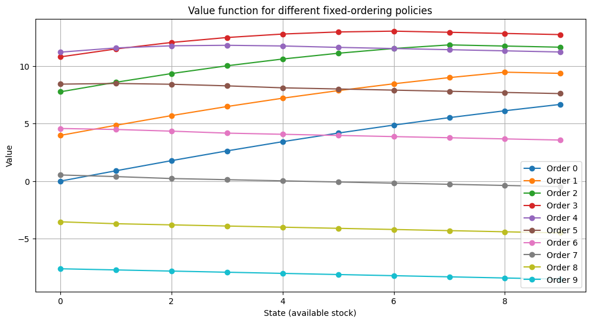

```python
all_values = np.zeros((m+1, m+1))  # all_values[a, s] = v_a(s)

for action in range(m+1):
    # Determinictic policy (always order 'action' items)
    pi = np.zeros((m+1, m+1))
    pi[:, action] = 1.0

    v_pi = env.value_policy(pi, gamma)
    all_values[action, :] = v_pi
    print(f"Policy a={action}: v_avg = {np.mean(v_pi):.2f}")

# Plot
plt.figure(figsize=(12, 6))
for action in range(m+1):
    plt.plot(range(m+1), all_values[action, :], marker='o', label=f'Order {action}')
plt.xlabel('State (available stock)')
plt.ylabel('Value')
plt.title('Value function for different fixed-ordering policies')
plt.legend()
plt.grid(True)
plt.show()
```

### **Q1.3 - Best Fixed-Ordering Policy**

```python
best_action = np.argmax(np.mean(all_values, axis=1))
print(f"The best fixed-ordering policy: order {best_action} items")
```

```
The best fixed-ordering policy: order 3 items
```

**Observation:** The average demand is $d=4$, so ordering $3$ helps to maintain stock close to the average demand.

### **Q1.4 - How do we know that there are better policies than the fixed-ordering ones?**

Fixed-ordering policies **don't take the current state ($S_t$ i.e. the available stock) into account**. However, an optimal policy $\pi_*$ should adapt its action to the stateby ordering more when the stock is low and less (or nothing) when the stock is already high.

Indeed, if you order too little, you miss sales **(opportunity cost $f$)**. If you order too much, you pay **storage cost $h$** and **saturate the warehouse $m$**.

### Q2. Computing the Optimal Policy

1. Obtain the optimal policy by **implementing the Policy Iteration algorithm** (use the `env.value_policy` to compute the value function).
2. **How do you know that it has converged?**
3. **What does the optimal policy do?**
4. **Comment the form of the value function.**

### **Q2.1 - Optimal Policy by implementing the Policy Iteration algorithm**

```python
# Q2 - Policy Iteration

def policy_iteration(env, gamma, max_iter=100, verbose=True):
    m = env.m

    pi = np.ones((m+1, m+1)) / (m+1)    #random policy (uniformly distributed)

    r = env.reward_function()
    p = env.transition_function()

    iteration = 0
    converged = False

    while not converged and iteration < max_iter:
        iteration += 1

        #Step 1: Policy evaluation
        v_pi = env.value_policy(pi, gamma)

        # Step 2: Policy improvement (greedy)
        pi_new = np.zeros((m+1, m+1))

        for s in range(m+1):
            # compute Q(s,a) for all actions
            q_values = np.zeros(m+1)
            for a in range(m+1):
                q_values[a] = r[s, a] + gamma * np.dot(p[s, a, :], v_pi)

            # Greedy policy (select the best action)
            best_action = np.argmax(q_values)
            pi_new[s, best_action] = 1.0

        # Check for convergence
        if np.allclose(pi, pi_new):
            converged = True
            if verbose:
                print(f"Convergence reached at iteration {iteration}")

        pi = pi_new

        if verbose and iteration % 5 == 0:
            print(f"Iteration {iteration}, v_avg = {np.mean(v_pi):.3f}")

    # Final Value
    v_star = env.value_policy(pi, gamma)

    return pi, v_star, iteration

pi_star, v_star, n_iter = policy_iteration(env, gamma)
```

```
Convergence reached at iteration 2
```

### **Q2.2 - Convergence**

The Policy Improvement Lemma states that if the greedy policy $g_+(v_{\pi})$ is identical to $\pi$, then $v_{\pi}$ must satisfy the Bellman Optimality Equation, meaning **$v_{\pi}$ is the optimal value function $v_*$** and **$\pi$ is the optimal policy $\pi_*$**

And we have a **stopping criterion:** Convergence is achieved when the Policy Improvement step yields the same policy that was just evaluated.

Then, convergence is detected because **the policy $\pi$ no longer changes between $2$ successive iterations** (stability of $\pi$).

(Since the state space $\mathcal{S}$ and action space $\mathcal{A}$ are finite, the policy iteration algorithm is guaranteed to converge to the optimal policy $\pi_*$ in a **finite number of iterations** (at most $|\mathcal{A}|^{|\mathcal{S}|}$).)

### **Q2.3 - Optimal Policy**

```python
optimal_actions = np.argmax(pi_star, axis=1)
for s in range(m+1):
    print(f"  État s={s}: Commander {optimal_actions[s]} items")
```

```
  État s=0: Commander 5 items
  État s=1: Commander 4 items
  État s=2: Commander 3 items
  État s=3: Commander 2 items
  État s=4: Commander 1 items
  État s=5: Commander 0 items
  État s=6: Commander 0 items
  État s=7: Commander 0 items
  État s=8: Commander 0 items
  État s=9: Commander 0 items
```

```python
threshold = optimal_actions[0]
print(f"Target level = {threshold} items")
```

```
Target level = 5 items
```

**Interprétation:** The optimal policy is a **threshold policy**: The agent's action aims to bring the stock up to this **target level**, or as close as possible given the capacity constraint $m$

### **Q2.4 - Shape of the value function**

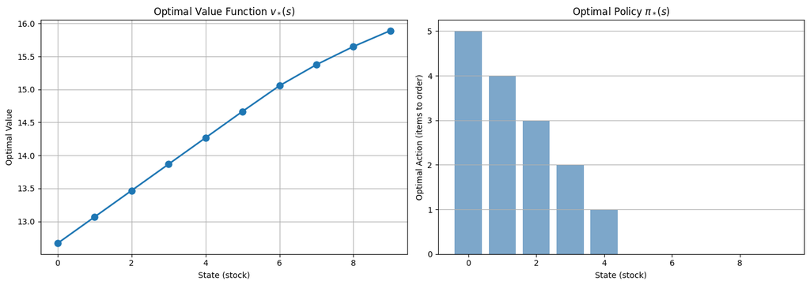

```python
plt.figure(figsize=(14, 5))

plt.subplot(1, 2, 1)
plt.plot(range(m+1), v_star, marker='o', linewidth=2, markersize=8)
plt.xlabel('State (stock)')
plt.ylabel('Optimal Value')
plt.title('Optimal Value Function $v_*(s)$')
plt.grid(True)

plt.subplot(1, 2, 2)
plt.bar(range(m+1), optimal_actions, alpha=0.7, color='steelblue')
plt.xlabel('State (stock)')
plt.ylabel('Optimal Action (items to order)')
plt.title('Optimal Policy $\pi_*(s)$')
plt.grid(True, axis='y')

plt.tight_layout()
plt.show()
```

**Observations:** The optimal value $v_*$ is **increasing with stock** (up to a certain point). This upward trend reflects that having available stock allows the agent to satisfy demand, thus maximizing sales profit ($f$).

Moreover, the shape of the function is concave because the marginal benefit of additional stock decreases as sales are saturated, while maintenance costs $h$ and the risk of exceeding the maximal capacity $m$ increase with the stock level.

### Q3. Q Learning

1. **Implement the asynchronous Q-Learning algorithm using the purely random policy (all actions selected uniformly) as the exploration policy** from a single trajectory of length $n = 10,000$ (note: this requires only about 10 lines of code).
2. **Plot the convergence of the algorithm towards the optimal policy**, first by monitoring the **convergence of the state-action value table** $Q_t$ in $\|\cdot\|_\infty$ norm.
3. Also plot **the convergence of the associated greedy policy** $\pi_{t+}(s) = \arg\max_a Q_t(s,a)$. **How does it relate to the previous plot?**
4. **Test different schemes of decrease** of the learning rate, following the course guidelines, and **explain the behaviors that you observe**.

### **Q3.1 - Asynchronous Q Learning Algorithm**

According to the course, the Q-Learning algorithm performs off-policy learning of the optimal Q-Value $q_*$ by recursively updating an estimate $Q_t$: $$Q_{t+1}(S_t, A_t) = Q_t(S_t, A_t) + \alpha(N_t(S_t, A_t)) [X_t + \gamma \max_a Q_t(S_{t+1}, a) - Q_t(S_t, A_t)]$$

with:

- LR: $\alpha(n) = n^{-\beta} \text{ where } \beta \in (0.5, 1]$
- visit count: $n = N_t(S_t, A_t)$ for the state-action pair $(S_t, A_t)$

  Convergence to the optimal Q-value [Bertsekas & Tsitsiklis, 1996] is established if:
- **Robbins-Monro conditions:** $\Sigma_t \alpha_t = \infty$ and $\Sigma_t \alpha_t^2 < \infty$ (satisfied when $\alpha(n) = n^{-\beta}$ with $\beta \in (0.5, 1]$)
- **Exploration condition:** Each state-action pair $(s,a)$ must be visited infinitely often (guaranteed by the uniform exploration policy).

```python
# Q3 - Q-Learning

def q_learning(env, n, beta=0.6, gamma=0.875):
    m = env.m

    Q = np.zeros((m+1, m+1))
    N = np.zeros((m+1, m+1), dtype=int)

    history_Q_error = []
    history_policy_changes = []

    # Compute Q*
    _, v_star, _ = policy_iteration(env, gamma, verbose=False)
    r = env.reward_function()
    p = env.transition_function()
    Q_star = np.zeros((m+1, m+1))
    for s in range(m+1):
        for a in range(m+1):
            Q_star[s, a] = r[s, a] + gamma * np.dot(p[s, a, :], v_star)

    # environnement init.
    env.reset(np.random.randint(0, m+1))
    # previous greedy policy
    prev_greedy = np.argmax(Q, axis=1)

    for t in range(n):
        s = env.state
        a = np.random.randint(0, m+1) #Uniform exploration policy

        x = env.step(a)
        s_next = env.state
        N[s, a] += 1
        alpha = np.power(N[s, a], -beta)

        # Off-policy update (Q-Learning)
        Q[s, a] = Q[s, a] + alpha * (x + gamma * np.max(Q[s_next, :]) - Q[s, a])

        # convergence (every 50 steps)
        if t % 50 == 0:
            error = np.max(np.abs(Q - Q_star))
            history_Q_error.append(error)

            current_greedy = np.argmax(Q, axis=1)
            policy_diff = np.sum(current_greedy != prev_greedy)
            history_policy_changes.append(policy_diff)
            prev_greedy = current_greedy.copy()

    return Q, history_Q_error, history_policy_changes

Q_learned, errors, policy_changes = q_learning(env, n=10000, beta=0.6)
```

### **Q3.2 & Q3.3**

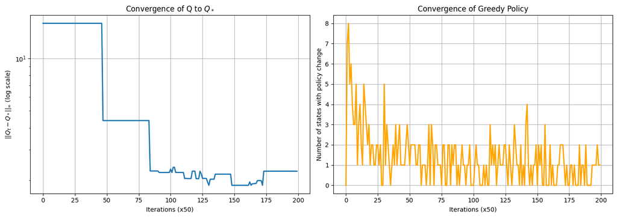

```python
# Q3.2 - Q Table Convergence
plt.figure(figsize=(14, 5))

plt.subplot(1, 2, 1)
plt.semilogy(range(len(errors)), errors, linewidth=2)
plt.xlabel('Iterations (x50)')
plt.ylabel('$||Q_t - Q_*||_\infty$ (log scale)')
plt.title('Convergence of Q to $Q_*$')
plt.grid(True)

# Q3.3 - Greedy Policy Convergence
plt.subplot(1, 2, 2)
plt.plot(range(len(policy_changes)), policy_changes, linewidth=2, color='orange')
plt.xlabel('Iterations (x50)')
plt.ylabel('Number of states with policy change')
plt.title('Convergence of Greedy Policy')
plt.grid(True)

plt.tight_layout()
plt.show()
```

### **Q3.4 - Comparison of different learning rate decay schemes**

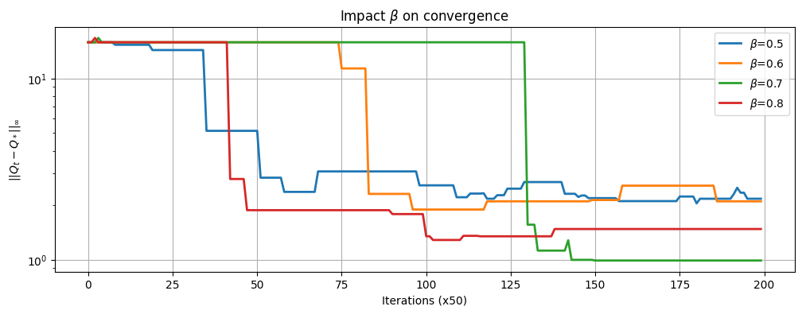

```python
betas = [0.5, 0.6, 0.7, 0.8]
plt.figure(figsize=(12, 4))

for i, beta in enumerate(betas):
    Q_temp, errors_temp, _ = q_learning(env, n=10000, beta=beta)
    plt.plot(range(len(errors_temp)), errors_temp, label=f'$\\beta$={beta}', linewidth=2)

plt.semilogy()
plt.xlabel('Iterations (x50)')
plt.ylabel('$||Q_t - Q_*||_\infty$')
plt.title('Impact $\\beta$ on convergence')
plt.legend()
plt.grid(True)
plt.show()
```

**Observations:**

Convergence conditions: $\sum \alpha_n = \infty$ and $\sum \alpha_n^2 < \infty$ are satisfied for $\beta \in (0.5, 1]$ when $\alpha_n = n^{-\beta}$

### Q4. Policy Gradient

We will now consider using policy gradient from a set of simulated trajectories using the REINFORCE formula to approximate the gradient of the value function. To do so, we consider a log-linear parameterization of the policy and provide the two utility functions below.

`policy_features` Computes a $2(m+1)$--dimensional feature vector $\phi(s,a)$ corresponding to the state-action pair $(s,a)$.

`policy_choice` Computes the vector $\pi_\theta(s,:)$ of action probabilities using the softmax operator: $$ \pi_\theta(s,a) = \frac{\exp\left(\theta^T \phi(s,a)\right)}{\sum_{a'=0}^m \exp\left(\theta^T \phi(s,a')\right)} $$ You should check from the code that the matrix $(\theta^T \phi(s,a))_{0\leq s,a \leq n}$ is a weighted sum of the $m+1$ fixed ordering policies and of the $m+1$ threshold policies (which you should have met already...)

```python
# Policy gradient utility functions (do NOT modify this code block)

def policy_features(s, a, m):
    """Returns the feature vector corresponding to state (s,a)."""
    f = np.zeros(2*(m+1))
    # Index of the fixed ordering policy that is non zero in (s,a)
    f[a] = 1
    # Indices of the threshold policies that are non zero in (s,a)
    if (s+a <= m):
        f[(m+1)+s+a] = 1
    if (a == 0):
        for i in range(0,s+1):
            f[(m+1)+i] = 1
    return f

def policy_choice(s, m,theta):
    """Returns the vector of action probabilities pi(s,:) corresponding to state s and parameter theta."""
    pi = np.zeros(m+1)
    # Note : Computation in log to avoid numerical underflows
    for a in range(m+1):
        pi[a] = np.dot(policy_features(s, a, m), theta)
    pi = pi - np.max(pi)
    pi = np.exp(pi)/np.sum(np.exp(pi))
    return pi
```

1. **Code a function** `policy_gradient` that computes the gradient $\nabla_\theta \log\pi_\theta(s,a)$. First **write in a text block the LaTeX formula implemented by the function, explaining how you obtain this formula.**
2. **Implement the policy gradient algorithm** approximating the gradient using the REINFORCE formula $$ \sum_{t=0}^{n} \gamma^t \left(\sum_{i=0}^{n} \gamma^i X_{t+i} \right) \nabla_\theta \log \pi_\theta(S_t, A_t) $$ computed on a trajectory of length 35 started from a random initial state. To do so, complete the code template provided below (please note that at least a few hundred SGD updates are required to observe convergence).
3. **Monitor the convergence of the algorithm by plotting the difference between the mean of the optimal value function and the mean of the value functions corresponding to successive values of $\theta$. Explain what the mean corresponds to?**
4. **Run the algorithm several times with the same and then different parameters (number of iterations, learning rate decrease schedule). What do you observe?**

### **Q4.1 - `policy_gradient`**

#### **1. Softmax Policy (Log-Linear)**

The softmax policy for action $a$ in state $s$ is defined as: $$ \pi_\theta(s,a) = \frac{\exp(\theta^T \phi(s,a))}{Z_s} $$ where $Z_s$ is the normalization term: $$ Z_s = \sum_{a'=0}^m \exp(\theta^T \phi(s,a')) $$

#### **2. Log-Probability**

$$ \log \pi_\theta(s,a) = \theta^T \phi(s,a) - \log Z_s $$

#### **3. Gradient Calculation $\nabla_\theta \log \pi_\theta(s,a)$**

We calculate the gradient with respect to $\theta$:

$$ \nabla_\theta \log \pi_\theta(s,a) = \nabla_\theta [\theta^T \phi(s,a)] - \nabla_\theta [\log Z_s] $$

**Step 3.1: Applying the Chain Rule** $$ \nabla_\theta [\log Z_s] = \frac{\nabla_\theta Z_s}{Z_s} $$

**Step 3.2: Calculating $\nabla_\theta Z_s$** $$ \nabla_\theta Z_s = \nabla_\theta \left[ \sum_{a'} \exp(\theta^T \phi(s,a')) \right] = \sum_{a'} \exp(\theta^T \phi(s,a')) \phi(s,a') $$

**Step 3.3: Substituting into Gradient Formula** $$ \nabla_\theta \log \pi_\theta(s,a) = \phi(s,a) - \frac{\sum_{a'} \exp(\theta^T \phi(s,a')) \phi(s,a')}{Z_s} $$

**Step 3.4: Final Simplification** $$ \nabla_\theta \log \pi_\theta(s,a) = \phi(s,a) - \sum_{a'} \left[ \frac{\exp(\theta^T \phi(s,a'))}{Z_s} \right] \phi(s,a') $$

Since the term in brackets is exactly $\pi_\theta(s,a')$, we arrive at the final, expected form: $$ \nabla_\theta \log \pi_\theta(s,a) = \phi(s,a) - \sum_{a'} \pi_\theta(s,a') \phi(s,a') $$

#### **4. Final Interpretation**

The gradient is the difference between the feature vector for the chosen action, $\phi(s,a)$, and the expected feature vector under the current policy, $\mathbb{E}_{A' \sim \pi_\theta(s, \cdot)}[\phi(s,A')]$: $$ \nabla_\theta \log \pi_\theta(s,a) = \phi(s,a) - \mathbb{E}_{A' \sim \pi_\theta(s, \cdot)}[\phi(s,A')] $$ This is the **Score Function** (or Likelihood Ratio) and is the core component of the REINFORCE algorithm.

```python
def policy_gradient(s, a, m, theta):
    # Feature vector
    phi_sa = policy_features(s, a, m)
    #Expected phi
    pi_s = policy_choice(s, m, theta)
    expected_phi = np.zeros_like(phi_sa)
    for a_prime in range(m+1):
        expected_phi += pi_s[a_prime] * policy_features(s, a_prime, m)

    return phi_sa - expected_phi
```

### **Q4.2 - Policy Gradient Algorithm (REINFORCE)**

The REINFORCE method estimates the gradient of the discounted value function $v_\theta(s)$:

$$ \nabla_\theta v_\theta(s) = \mathbb{E}_\theta[\sum_{t\ge0} \gamma^t \left(\sum_{i\ge0} \gamma^i X_{t+i}\right) \nabla_\theta \log \pi_\theta(S_t, A_t) \mid S_0=s]$$

**Monte Carlo Estimator (REINFORCE)**

For implementation, the expectation is approximated using a single simulated trajectory of length $n$. The term $\sum_{i=t}^{n-1} \gamma^{i-t} X_i$ represents the **Discounted Return** from time $t$ onward:

$$ grad \approx \sum_{t=0}^{n-1} \gamma^t \left(\sum_{i=t}^{n-1} \gamma^{i-t} X_i\right) \nabla_\theta \log \pi_\theta(S_t, A_t) $$

(assuming the agent starts from a **random initial state**)

**SGD Parameters**

- $n=35$: trajectory length
- $nb\_iter$: number of SGD iterations
- $lr\_init, lr\_decay$: the learning rate $\alpha_k$ follows a decreasing scheme: $\alpha_k = lr\_init \times (1+k)^{-lr\_decay}$

```python
def reinforce(env, gamma, n=35, nb_iter=300, lr_init=0.1, lr_decay=0.6):
    m = env.m
    theta = np.zeros(2*(m+1))

    pi_star, v_star, _ = policy_iteration(env, gamma, verbose=False)
    v_star_mean = np.mean(v_star)

    history_value_diff = []

    for i_iter in range(nb_iter):
        s0 = np.random.randint(0, m+1)
        env.reset(s0)
        trajectory = []

        for t in range(n):
            s = env.state

            # ON-POLICY
            pi_s = policy_choice(s, m, theta)
            a = np.random.choice(m+1, p=pi_s)
            x = env.step(a)

            trajectory.append((s, a, x))

        grad = np.zeros(2*(m+1))

        for t in range(n):
            s_t, a_t, _ = trajectory[t]

            G_t = 0.0
            discount = 1.0
            for i in range(t, n):
                G_t += discount * trajectory[i][2]
                discount *= gamma

            grad += (gamma ** t) * G_t * policy_gradient(s_t, a_t, m, theta)

        lr = lr_init * np.power(1 + i_iter, -lr_decay)
        theta += lr * grad

        if i_iter % 10 == 0:
            pi_current = np.zeros((m+1, m+1))
            for s in range(m+1):
                pi_current[s, :] = policy_choice(s, m, theta)
            v_current = env.value_policy(pi_current, gamma)
            v_current_mean = np.mean(v_current)

            diff = v_star_mean - v_current_mean
            history_value_diff.append(diff)

    return theta, history_value_diff
```

### **Q4.2 & Q4.3**

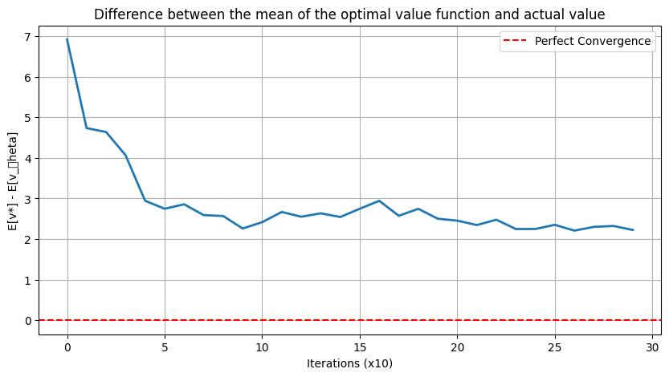

```python
## Q4.2 - REINFORCE Algo
theta_final, value_diffs = reinforce(env, gamma, n=35, nb_iter=300)

## Q4.3 - Convergence
plt.figure(figsize=(10, 5))
plt.plot(range(len(value_diffs)), value_diffs, linewidth=2)
plt.xlabel('Iterations (x10)')
plt.ylabel('E[v*] - E[v_\theta]')
plt.title('Difference between the mean of the optimal value function and actual value')
plt.grid(True)
plt.axhline(y=0, color='r', linestyle='--', label='Perfect Convergence')
plt.legend()
plt.show()
```

**Interpretation:** The mean represents the expected value across all possible states. This serves as a global metric for the policy's overall performance.

### **Q4.4**

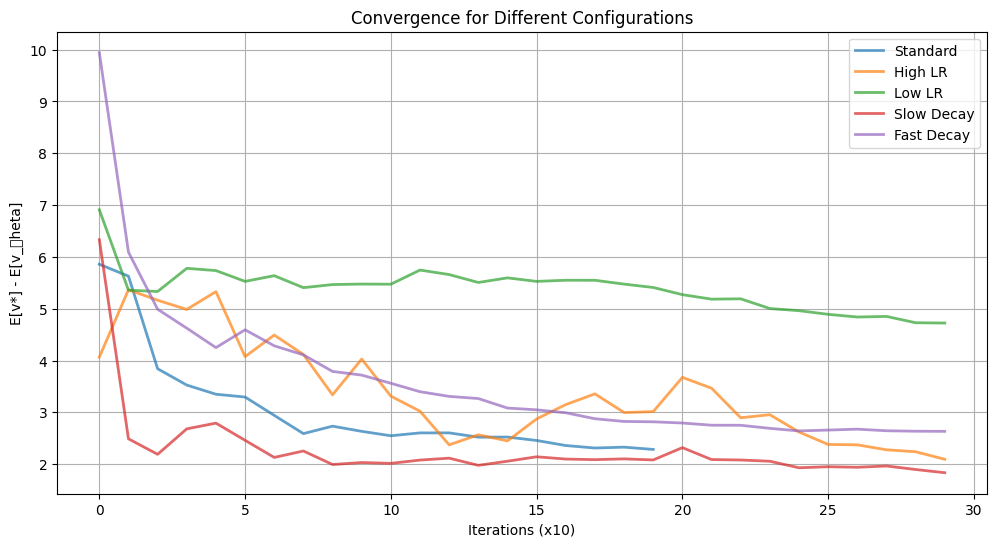

```python
configs = [
    (200, 0.1, 0.6, "Standard"),
    (300, 0.2, 0.6, "High LR"),
    (300, 0.05, 0.6, "Low LR"),
    (300, 0.1, 0.5, "Slow Decay"),
    (300, 0.1, 0.7, "Fast Decay")
]

plt.figure(figsize=(12, 6))

for nb_iter, lr_init, lr_decay, label in configs:
    _, diffs = reinforce(env, gamma, n=35, nb_iter=nb_iter,
                         lr_init=lr_init, lr_decay=lr_decay)
    plt.plot(range(len(diffs)), diffs, linewidth=2, label=label, alpha=0.7)

plt.xlabel('Iterations (x10)')
plt.ylabel('E[v*] - E[v_\theta]')
plt.title('Convergence for Different Configurations')
plt.legend()
plt.grid(True)
plt.show()
```

**Observations:**

- The algorithm is STOCHASTIC: convergence varies between runs.

```python
# --- Example code for the policy gradient algorithm (edit this block as needed) ---
n = 35
nb_iter = 200

theta = np.zeros(2*(m+1))
for i_iter in range(nb_iter):
    # Compute the REINFORCE approximation of the gradient of the value function from a run of length n
    # of the MDP initialized t a random state and using the policy corresponding to the current value of theta

    grad = np.zeros(2*(m+1))  # --- Something better than this is needed here! ---

    # Do a step of SGD update on theta
    theta += 0.1*np.power(1+i_iter, -0.6)*grad
```